# Example of fitting a food web model to data.

Owen Petchey

15 September, 2021

```r
library(rdryad)
library(janitor)
library(tidyverse)
library(here)

source("https://raw.githubusercontent.com/opetchey/dumping_ground/master/ADBM_shiny/Plot.matrix.r")
source(here("r/ADBM.functions.r"))
```

# Introduction

This report shows how the allometric diet breadth model of [Petchey et al (2008)](https://www.pnas.org/content/105/11/4191) was fit to empirical food web data. The report is basic and unrefined (purely functional in purpose).

Note that in the [supplementary information](https://www.pnas.org/content/pnas/suppl/2008/03/07/0710672105.DC1/10672SuppAppendix.pdf) Table S4 of Petchey et al (2008), the last names of the food webs in the last two rows are swapped: the values in the last row are for the Ythan food web.

# Empirical data

## 2008 Ythan data

This is the dataset used in Petchey et al (2008). Owen, who was responsible for data management and processing, does not have a record of how this dataset was created.

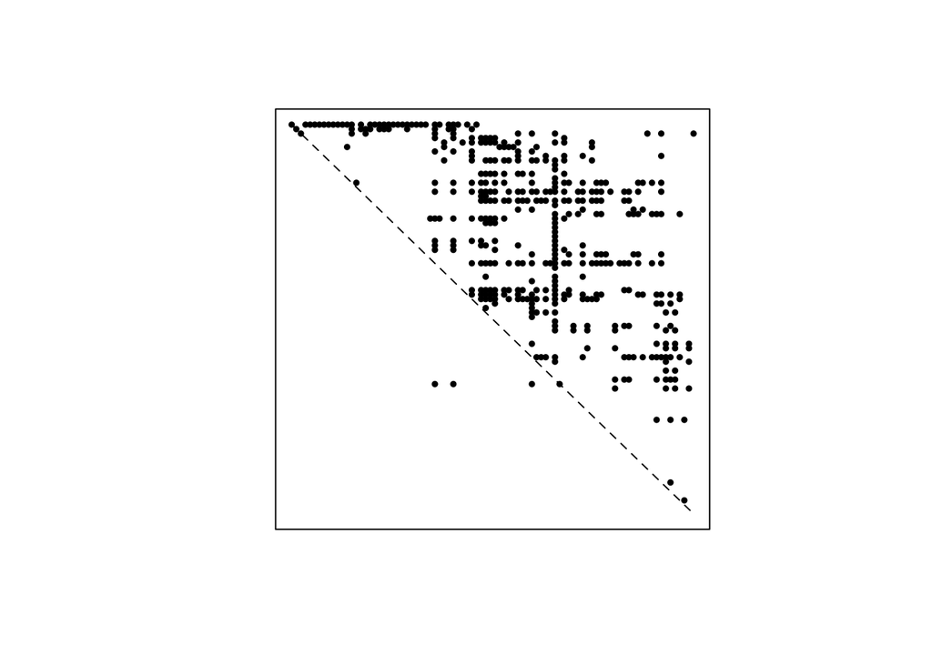

```r
ythan2008.all.web.info <- readRDS(here("data/2008_empirical_data/Ythan.web.2008.RDS"))
Plot.matrix(ythan2008.all.web.info$predation.matrix)
box()
```

## Ythan data from Cirtwill & Eklöf (2020)

Here a version of the [Ythan dataset on Dryad](https://doi.org/10.5061/dryad.1mv20r6) (from [Cirtwill & Eklöf 2020](https://onlinelibrary.wiley.com/doi/10.1111/ele.12955)) is downloaded and then made ready. Code is hidden as there is quite a lot of uninteresting manipulation. The food web is somewhat different from that used in Petchey et al (2008).

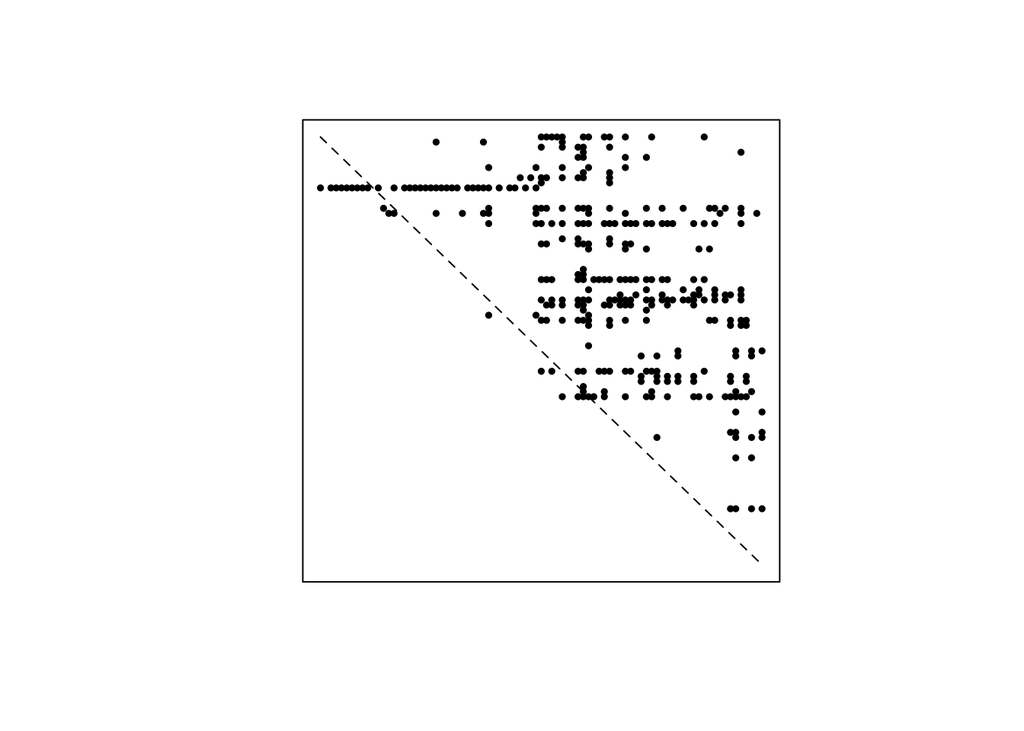

# Fitting the model

## Starting parameter values

The search algorithm can get stuck in local optima, so the search is started multiple times each from a different location in parameter space. Those starting parameter values are loaded from a text file:

```r
ratio_initial_pars <- read.csv(here("pars/ratio.initial.pars.txt"),
                               header = FALSE)
```

## Fit model to 2008 Ythan data

Here the outcome is the same as in Petchey et al (2008).

```r
NM.RH.web_2008 <- NM.ratio(ythan2008.all.web.info, ratio_initial_pars)
```

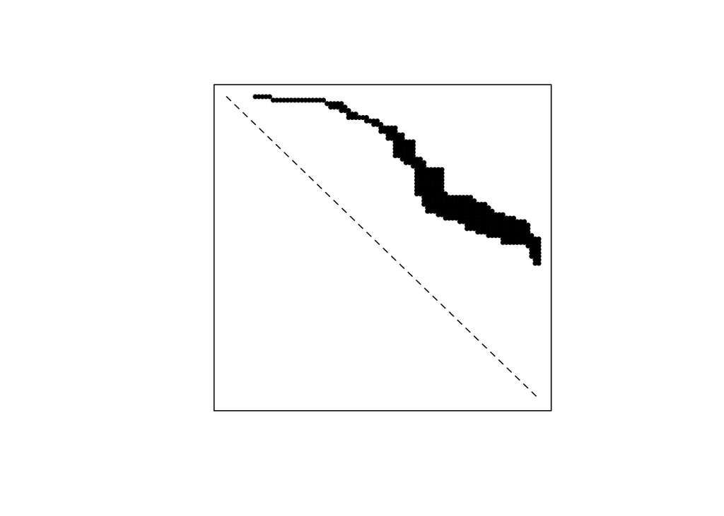

```r
Plot.matrix(NM.RH.web_2008$web)
box()
```

```r
NM.RH.web_2008$power
```

```
## [1] 0.1882353
```

```r
NM.RH.web_2008$pars
```

```
##             e             n            ni             a         ai.V1
##  1.000000e+00  1.000000e+00 -7.500000e-01  1.825057e-17 -1.984001e+00
##         aj.V2           r.a        r.b.V3
##  2.188542e+00  1.000000e+00  3.231239e-04
```

```r
sum(NM.RH.web_2008$web)
```

```
## [1] 425
```

```r
sum(ythan2008.all.web.info$predation.matrix)
```

```
## [1] 425
```

## Fit model to dryad Ythan data

```r
NM.RH.web_dryad <- NM.ratio(ythandryad.all.web.info, ratio_initial_pars)
```

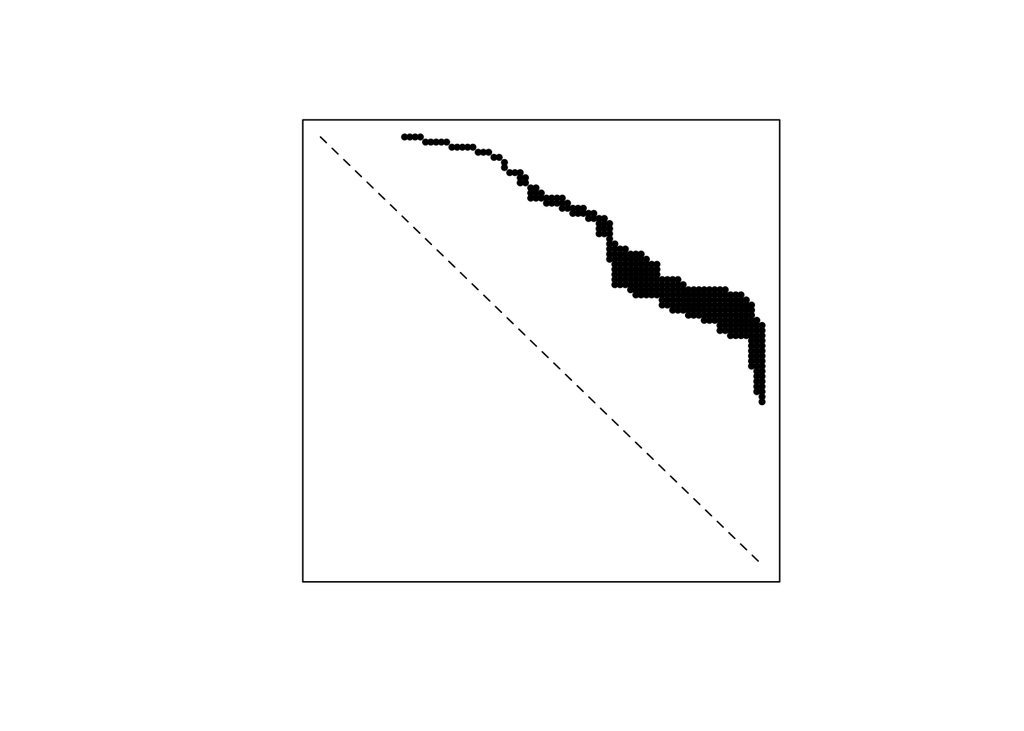

```r
Plot.matrix(NM.RH.web_dryad$web)
box()
```

```r
NM.RH.web_dryad$power
```

```
## [1] 0.1751592
```

```r
NM.RH.web_dryad$pars
```

```
##             e             n            ni             a         ai.V1
##  1.000000e+00  1.000000e+00 -7.500000e-01  3.508671e-07 -4.750000e-01
##         aj.V2           r.a        r.b.V3
##  5.250000e-01  1.000000e+00  1.000000e-03
```

```r
sum(NM.RH.web_dryad$web)
```

```
## [1] 314
```

```r
sum(ythandryad.all.web.info$predation.matrix)
```

```
## [1] 316
```

# Using 2008 parameter estimates

Using the 2008 parameter estimates gives the same results as in Petchey et al (2008).

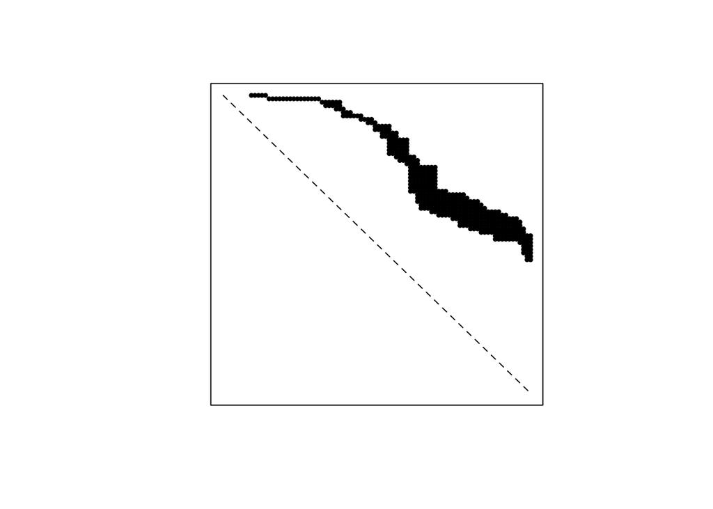

```r
a_2008 <- 1.8e-17
ai_2008 <- -1.98
aj_2008 <- 2.19
b_2008 <- 3.22e-4

EHL_2008 <- Ratio.allometric.EHL(M = ythan2008.all.web.info$species.sizes,
                           e = 1,
                           r.a = 1, r.b = b_2008,
                           a = a_2008, ai = ai_2008, aj = aj_2008,
                           n = 1, ni=-3/4)
web_2008 <- Get.web(EHL_2008)
Plot.matrix(web_2008)
box()
```

```r
Compare.links(web_2008, ythan2008.all.web.info$predation.matrix)
```

```
## [1] 0.1882353
```